# Norma

Tragedia lirica in zwei Akten (1831)

Musik von Vincenzo Bellini  
Text von Felice Romani

[Tickets](https://staatsoper-berlin.eventim-inhouse.de/webshop/webticket/shop?language=de&production=1204)

[video not shown]

Der Wille zum Widerstand gegen die Römer wächst unter den Galliern. Norma soll endlich das Zeichen zum Aufruhr gegen die Unterdrücker geben. Doch sie zögert vor dem Hintergrund eines Gewissenskonflikts: Mit dem Römer Pollione hat Norma zwei Kinder, die sie vor der Öffentlichkeit versteckt hält. Als sie erfahren muss, dass Pollione Adalgisa liebt und mit ihr fliehen will, scheint ihre Situation ausweglos. Wenn Norma ihr Doppelleben preisgibt, setzt sie ihr Ansehen und das ihrer Kinder aufs Spiel.

Vincenzo Bellinis 1831 uraufgeführte Erfolgsoper gilt als Inbegriff des Belcanto – und bietet doch so viel mehr als bloßen Schöngesang. Bereits Richard Wagner erkannte, dass die ungemein dramatische Musik ein „Seelengemälde“ der Protagonistin beschreibt. Der Regisseur Vasily Barkhatov unterstreicht in seiner Lesart Normas Zerrissenheit zwischen ihrer öffentlichen Funktion und persönlichen Gefühlen vor dem Hintergrund einer politischen Revolution.

Festtage 2025

Montag, 21. April 2025  
18.00 Uhr

[Staatsoper Unter den Linden](https://www.staatsoper-berlin.de/de/ihr-besuch/anfahrt/staatsoper-unter-den-linden.35/)

[Tickets](https://staatsoper-berlin.eventim-inhouse.de/webshop/webticket/shop?language=de&event=18220)

Dauer: ca. 3 h inklusive einer Pause

Sprache: In italienischer Sprache mit deutschen und englischen Übertiteln

Altersempfehlung: ab 14 Jahren

Einblick am 7. April 2025  
Vorwort 45 Minuten vor Vorstellungsbeginn im Apollosaal

## Besetzung

- Musikalische Leitung:

  [Francesco Lanzillotta](https://www.staatsoper-berlin.de/de/kuenstler/francesco-lanzillotta.3458/)
- Inszenierung:

  [Vasily Barkhatov](https://www.staatsoper-berlin.de/de/kuenstler/vasily-barkhatov.3459/)
- Spielleitung:
  - [José Darío Innella](https://www.staatsoper-berlin.de/de/kuenstler/jose-dario-innella.3590/),
  - [Marcin Łakomicki](https://www.staatsoper-berlin.de/de/kuenstler/marcin-lakomicki.1324/)
- Bühne:

  [Zinovy Margolin](https://www.staatsoper-berlin.de/de/kuenstler/zinovy-margolin.3460/)
- Kostüme:

  [Olga Shaishmelashvili](https://www.staatsoper-berlin.de/de/kuenstler/olga-shaishmelashvili.3461/)
- Licht:

  [Alexander Sivaev](https://www.staatsoper-berlin.de/de/kuenstler/alexander-sivaev.3462/)
- Kampfchoreographie:

  [Ran Arthur Braun](https://www.staatsoper-berlin.de/de/kuenstler/ran-arthur-braun.2820/)
- Einstudierung Chor:

  [Dani Juris](https://www.staatsoper-berlin.de/de/kuenstler/dani-juris.3290/)
- Dramaturgie:
  - [Kai Weßler](https://www.staatsoper-berlin.de/de/kuenstler/kai-wessler.3463/),
  - [Christoph Lang](https://www.staatsoper-berlin.de/de/kuenstler/christoph-lang.2954/)
- Norma:

  [Rachel Willis-Sørensen](https://www.staatsoper-berlin.de/de/kuenstler/rachel-willis-soerensen.2647/)
- Pollione:

  [Dmitry Korchak](https://www.staatsoper-berlin.de/de/kuenstler/dmitry-korchak.1522/)
- Adalgisa:

  [Elmina Hasan](https://www.staatsoper-berlin.de/de/kuenstler/elmina-hasan.3464/)
- Oroveso:

  [Riccardo Fassi](https://www.staatsoper-berlin.de/de/kuenstler/riccardo-fassi.2733/)
- Clotilde:

  [Maria Kokareva](https://www.staatsoper-berlin.de/de/kuenstler/maria-kokareva.3270/)
- Flavio:

  [Junho Hwang](https://www.staatsoper-berlin.de/de/kuenstler/junho-hwang.3579/)
- - [Staatsopernchor](https://www.staatsoper-berlin.de/de/kuenstler/staatsopernchor.1020/),
  - [Staatskapelle Berlin](https://www.staatsoper-berlin.de/de/kuenstler/staatskapelle-berlin.1019/)

## Medien

[figure not shown]

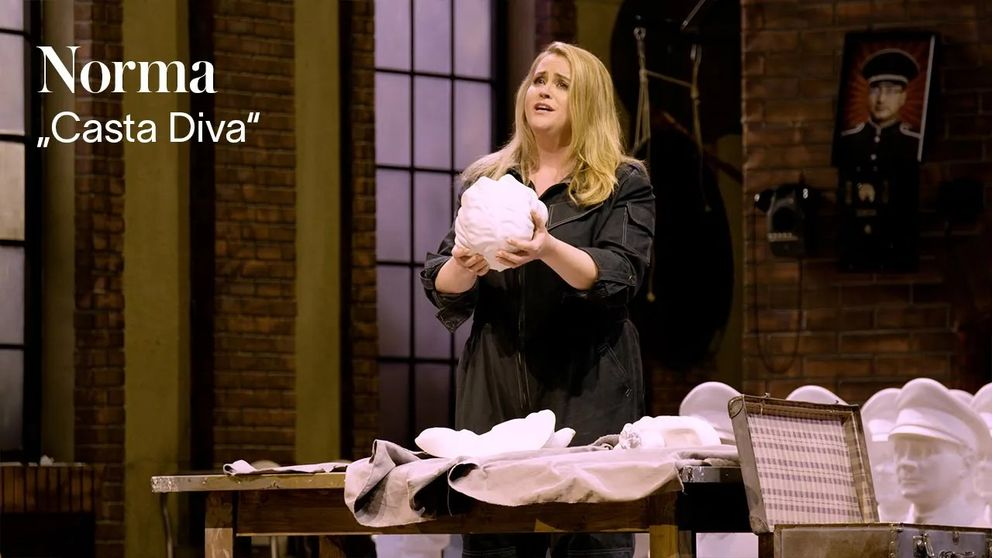

Audio

[figure not shown]

[figure not shown]

[figure not shown]

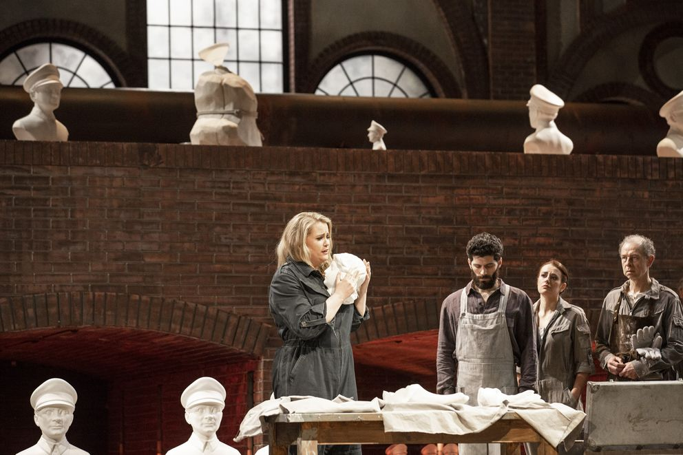

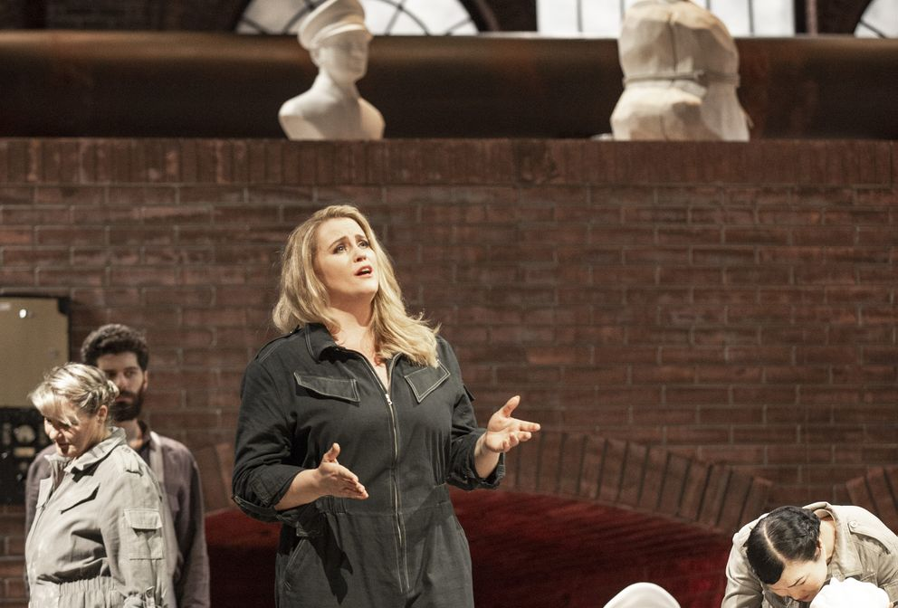

> „Ein rundum gelungener Abend, der noch lange nachhallt.“

> B.Z.

> „Uneingeschränkten Glanz verströmt Elmina Hasan als Adalgisa: Ihr Sopran zieht sofort alle Aufmerksamkeit auf sich, weil er Menschlichkeit ausstrahlt, weil die Melodien aus tiefstem Herzen aufzusteigen scheinen. Von berührender Noblesse ist auch Riccardo Fassi als Oroveso.“

> Tagesspiegel

> „Gesungen und gespielt wurde grandios, unter der Leitung von Francesco Lanzilotta, der Barkhatovs Inszenierung im Februar bereits in Wien dirigierte.“

> B.Z.

> „Wie da Rachel Willis-Sørensen in der Titelpartie und Elmina Hasan aneinander aufglühten und zwischendrin Dmitry Korchaks Pollione mit Verve und tenoraler Macht mitmischte: Das war großes Theater [...].“

> Frankfurter Allgemeine Zeitung

[Programmbuch Download](https://www.staatsoper-berlin.de/downloads-b/de/produktion/15538/programmbuch/ff3a435ceafcff37aa94937ba68bbefd/Norma_ProgBuch_13042025_F2_web_K01.pdf)

- Koproduktion mit dem MusikTheater an der Wien
- Mit freundlicher Unterstützung

[figure not shown]

[interactive chart not shown]